# Research Design and Hypotheses

Sherri Verdugo

September 22, 2014

## How to conceptualize the hypothesis process

1. Formulate a general question based on research
2. This is the basic process for a single sample
3. Questions:
   - How do we answer questions in statistics?
   - How can we use sample data?
4. Setting up testing procedures

## Research Design Steps

- Define the purpose of your project.
  - is it exploratory, descriptive, or explanatory?
- Specify the meanings of each concept you want to study
- Select a research method?
  - for this class: previously collected data
- How will you measure the results?
  - for this class: previously collected data
  - STATISTICAL HYPOTHESIS TESTING
- Collect empirical data:
  - obtain a data set or use one that is provided for you in the writing assignment folder
- Process the data (or use clean provided data)
  - this is a process of preparing the data for analysis
- Analyze the data
  - STATISTICS
- Report your findings

## Research Proposal Steps: Writting Assignment

*Elements of a Research Paper*

- Title Page
- Abstract
  - Key Words
- Introduction
  - Problem or Objective
  - Literature Review
  - Hypotheses
- Methods
  - Subjects for study
  - Measurement
  - Data Collection
- Results
  - Scheduled: Late October and November 2014
  - Analysis
- Discussion
  - Findings
- Conclusions
  - Limitations
  - Recommendations
- References
- Appendix

## Research Scenarios

Research and watching Charlie Bartlet (movie) has resulted in your proposed idea that:

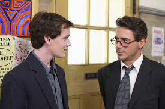

- Sharing prescription drugs with others can be dangerous.
- Is this common in a high school setting?
- So what do we do?
- We can write a set of statements (hypotheses) that we can test

## Hypotheses

- The null hypothesis, $H_0$
  - claim about a population characteristic
  - initially assumed to be true
- The alternative hypothesis, $H_1$ or $H_a$
  - competing claim
  - a difference between the two items exists
- Both $H_0$ and $H_a$ are about the population!
- We want to determine if the claims are true

## Mutually Exhaustive and Exclusive!

- Mutually Exclusive: two events cannot occur at the same time
- Mutually Exhaustive: includes all the possible outcomes
- Meaning that we have considered all possibilities and that if you are in one group then you are not in the other group.

## A Tale of Two Stories: Two Tailed Null

- Two tailed hypothesis: you are interested in both directions
  - Null includes the equal case
  - Alternative includes the does not equal case
- For our example: Null
  - $H_0:Null$ in words:
    - The transfer of prescription drugs in high school students is equal to the amount of transfer of prescription drugs in the general population (no difference).
  - $H_0$ in statistics:
    - The $\mu$ rate for the transfer of prescription drugs in high school = the $\mu$ rate for the transfer of prescription drugs in the general population.

## One-Tailed Null and Alternative

- A one-tailed test looks for an increase or decrease in the parameter

http://www.socialresearchmethods.net/kb/hypothes.php

## End goal of research

- We want to produce a research paper
- We want to make sure it is reproducible
- Provide instructions as to how the research was analyzed (reproducible)
- Encourage future research in the area that we are reporting on

## End goal of hypothesis design

To be able to test statistically the statements and look for significance.

We are now moving into the “inferential” part of statistics. Meaning, we will design hypothesis statements and test for statistical significance.